# European history in a nutshell - parte 3

Caronte Martina, Lo Giudice Federica, Sisti Sara

31 gennaio 2019

#### Installazione librerie

```r
library(tidyverse)
library(rvest)
library(magrittr)
library(rJava)
library(coreNLP)
library(NLP)
library(openNLP)
library(textclean)
library(tm)
library(wordcloud2)
library(dplyr)
library(text2vec)
library(RColorBrewer)
library(data.table)
library(monkeylearn)
library(leaflet)
library(utf8)
library(stringr)
library(networkD3)
library(dygraphs)
library(xts)
library(lexicon)
```

#### Webscraping

Abbiamo deciso di utilizzare la tecnica del webscraping ai fini di costruire il nostro dataset. Lo scraping è stato applicato a 60 pagine Wikipedia riguardanti 60 tra le più note città europee (elencate in [questo file](https://raw.githubusercontent.com/sarasixti/SLproject/master/dataset_cities_clean.txt)), di cui abbiamo scaricato la sezione riguardante la storia. Abbiamo creato una funzione **texts** che performa lo scraping prendendo come input la categoria (“history” in questo caso), gli indici dei paragrafi della categoria sulla pagina html Wikipedia, l’url della pagina. Abbiamo infine organizzato i testi ottenuti in un dataframe con 2 variabili contenenti: nome della città, testo.

```r
cities <- fread("https://raw.githubusercontent.com/sarasixti/SLproject/master/dataset_cities_clean.txt")
country<-cities$country
city_list<-cities$city
city_list<-city_list[-which(city_list=="Chisinau")]
city_list<-city_list[-which(city_list=="Monte Carlo")]
city_list<-city_list[-which(city_list=="Braga")]

categ <- "history"

texts<-function(category,indexes,city){
  base_url <- paste0("https://en.wikipedia.org/wiki/", city)
  webpage <- read_html(base_url)
  xpaths<-sapply(indexes,function(i) paste0('//*[@id="mw-content-text"]/div/p[',i,']'))
  category<-c()
  for (p in 1:length(xpaths)){
    category<-c(category,webpage %>% html_nodes(xpath = xpaths[p]) %>% html_text())
  }
  category<-gsub("\n", "", category)
  category<-paste(unlist(category),collapse="")
  return(category)
}

dataset_finale<-matrix(NA,nrow=length(city_list),ncol=length(categ))
colnames(dataset_finale)<-categ

#fill rows with history texts:
#Tirana
city<-city_list[1]
row<-which(city_list==city)
indexes_hist<-c(7:22)
history<-texts(categ[1],indexes_hist,city)
tirana_row<-matrix(history,nrow=1,ncol=length(categ))
dataset_finale[row,]<-tirana_row

#Vienna
city<-city_list[2]
row<-which(city_list==city)
indexes_hist<-c(10:25)
history<-texts(categ[1],indexes_hist,city)
vienna_row<-matrix(history,nrow=1,ncol=length(categ))
dataset_finale[row,]<-vienna_row

#Minsk
city<-city_list[3]
row<-which(city_list==city)
indexes_hist<-c(8:29)
history<-texts(categ[1],indexes_hist,city)
minsk_row<-matrix(history,nrow=1,ncol=length(categ))
colnames(minsk_row)<-categ
rownames(minsk_row)<-city
dataset_finale[row,]<-minsk_row

#Brussels
city<-city_list[4]
row<-which(city_list==city)
indexes_hist<-c(9:23)
history<-texts(categ[1],indexes_hist,city)
bruss_row<-matrix(history,nrow=1,ncol=length(categ))
dataset_finale[row,]<-bruss_row

#Antwerp
city<-city_list[5]
row<-which(city_list==city)
indexes_hist<-c(5:26)
history<-texts(categ[1],indexes_hist,city)
antwerp_row<-matrix(history,nrow=1,ncol=length(categ))
dataset_finale[row,]<-antwerp_row

#Sarajevo
city<-city_list[6]
row<-which(city_list==city)
indexes_hist<-c(19:53)
history<-texts(categ[1],indexes_hist,city)
sarajevo_row<-matrix(history,nrow=1,ncol=length(categ))
dataset_finale[row,]<-sarajevo_row

#Sofia
city<-city_list[7]
row<-which(city_list==city)
indexes_hist<-c(19:43)
history<-texts(categ[1],indexes_hist,city)
sofia_row<-matrix(history,nrow=1,ncol=length(categ))
dataset_finale[row,]<-sofia_row

#zagreb
city<-city_list[8]
row<-which(city_list==city)
indexes_hist<-c(10:25)
history<-texts(categ[1],indexes_hist,city)
zagreb_row<-matrix(history,nrow=1,ncol=length(categ))
dataset_finale[row,]<-zagreb_row

#Nicosia
city<-city_list[9]
row<-which(city_list==city)
indexes_hist<-c(6:29)#change
history<-texts(categ[1],indexes_hist,city)
nicosia_row<-matrix(history,nrow=1,ncol=length(categ))
dataset_finale[row,]<-nicosia_row

#prague
city<-city_list[10]
row<-which(city_list==city)
indexes_hist<-c(7:41)
history<-texts(categ[1],indexes_hist,city)
prague_row<-matrix(history,nrow=1,ncol=length(categ))
dataset_finale[row,]<-prague_row

#Copenhagen
city<-city_list[11]
row<-which(city_list==city)
indexes_hist<-c(9:35)
history<-texts(categ[1],indexes_hist,city)
copen_row<-matrix(history,nrow=1,ncol=length(categ))
dataset_finale[row,]<-copen_row

#Tallin
city<-city_list[12]
row<-which(city_list==city)
indexes_hist<-c(14:31)
history<-texts(categ[1],indexes_hist,city)
tallin_row<-matrix(history,nrow=1,ncol=length(categ))
dataset_finale[row,]<-tallin_row

#Helsinki
city<-city_list[13]
row<-which(city_list==city)
indexes_hist<-c(10:19)
history<-texts(categ[1],indexes_hist,city)
helsin_row<-matrix(history,nrow=1,ncol=length(categ))
dataset_finale[row,]<-helsin_row

#paris
city<-city_list[14]
row<-which(city_list==city)
indexes_hist<-c(10:41)
history<-texts(categ[1],indexes_hist,city)
paris_row<-matrix(history,nrow=1,ncol=length(categ))
dataset_finale[row,]<-paris_row

#Lyon
city<-city_list[15]
row<-which(city_list==city)
indexes_hist<-c(5:14)
history<-texts(categ[1],indexes_hist,city)
lyon_row<-matrix(history,nrow=1,ncol=length(categ))
dataset_finale[row,]<-lyon_row

#Marseille
city<-city_list[16]
row<-which(city_list==city)
indexes_hist<-c(9:11)
history<-texts(categ[1],indexes_hist,city)
marseille_row<-matrix(history,nrow=1,ncol=length(categ))
dataset_finale[row,]<-marseille_row


#Cologne
city<-city_list[17]
row<-which(city_list==city)
indexes_hist<-c(6:33)
history<-texts(categ[1],indexes_hist,city)
cologne_row<-matrix(history,nrow=1,ncol=length(categ))
dataset_finale[row,]<-cologne_row


#Berlin
city<-city_list[18]
row<-which(city_list==city)
indexes_hist<-c(8:22)
history<-texts(categ[1],indexes_hist,city)
berlin_row<-matrix(history,nrow=1,ncol=length(categ))
dataset_finale[row,]<-berlin_row

#Francoforte
city<-city_list[19]
row<-which(city_list==city)
indexes_hist<-c(18:38)#change
history<-texts(categ[1],indexes_hist,city)
frank_row<-matrix(history,nrow=1,ncol=length(categ))
dataset_finale[row,]<-frank_row

#Atene
city<-city_list[20]
row<-which(city_list==city)
indexes_hist<-c(10:18)
history<-texts(categ[1],indexes_hist,city)
athen_row<-matrix(history,nrow=1,ncol=length(categ))
dataset_finale[row,]<-athen_row

#Budapest
city<-city_list[21]
row<-which(city_list==city)
indexes_hist<-c(12:23)
history<-texts(categ[1],indexes_hist,city)
budapest_row<-matrix(history,nrow=1,ncol=length(categ))
dataset_finale[row,]<-budapest_row

#Reykjavik
city<-city_list[22]
row<-which(city_list==city)
indexes_hist<-c(3:12)
indexes_econ<-c(29:30)
indexes_cult<-c(37:43)
indexes_culin<-c(43)
history<-texts(categ[1],indexes_hist,city)
rey_row<-matrix(history,nrow=1,ncol=length(categ))
dataset_finale[row,]<-rey_row

#Dublin
city<-city_list[23]
row<-which(city_list==city)
indexes_hist<-c(7:21)
history<-texts(categ[1],indexes_hist,city)
dublin_row<-matrix(history,nrow=1,ncol=length(categ))
dataset_finale[row,]<-dublin_row

#Milan
city<-city_list[24]
row<-which(city_list==city)
indexes_hist<-c(7:23)
history<-texts(categ[1],indexes_hist,city)
milan_row<-matrix(history,nrow=1,ncol=length(categ))
dataset_finale[row,]<-milan_row
```

```r
#Naples
city<-city_list[25]
row<-which(city_list==city)
indexes_hist<-c(9:33)
history<-texts(categ[1],indexes_hist,city)
naples_row<-matrix(history,nrow=1,ncol=length(categ))
dataset_finale[row,]<-naples_row

#Rome
city<-city_list[26]
row<-which(city_list==city)
indexes_hist<-c(8:38)
history<-texts(categ[1],indexes_hist,city)
rome_row<-matrix(history,nrow=1,ncol=length(categ))
dataset_finale[row,]<-rome_row

#Riga
city<-city_list[27]
row<-which(city_list==city)
indexes_hist<-c(8:32)
history<-texts(categ[1],indexes_hist,city)
riga_row<-matrix(history,nrow=1,ncol=length(categ))
dataset_finale[row,]<-riga_row


#Vilinius
city<-city_list[28]
row<-which(city_list==city)
history<-texts(categ[1],indexes_hist,city)
vilinius_row<-matrix(history,nrow=1,ncol=length(categ))
dataset_finale[row,]<-vilinius_row

#Lussemburgo
city<-city_list[29]
row<-which(city_list==city)
indexes_hist<-c(7:18)
history<-texts(categ[1],indexes_hist,city)
lux_row<-matrix(history,nrow=1,ncol=length(categ))
dataset_finale[row,]<-lux_row

#Valletta
city<-city_list[30]
row<-which(city_list==city)
indexes_hist<-c(5:23)
history<-texts(categ[1],indexes_hist,city)
valletta_row<-matrix(history,nrow=1,ncol=length(categ))
dataset_finale[row,]<-valletta_row

#Podgorica
city<-city_list[31]
row<-which(city_list==city)
indexes_hist<-c(20:30)
history<-texts(categ[1],indexes_hist,city)
podg_row<-matrix(history,nrow=1,ncol=length(categ))
dataset_finale[row,]<-podg_row

#Amsterdam
city<-city_list[32]
row<-which(city_list==city)
indexes_hist<-c(7:21)
history<-texts(categ[1],indexes_hist,city)
amsterdam_row<-matrix(history,nrow=1,ncol=length(categ))
dataset_finale[row,]<-amsterdam_row

#Rotterdam
city<-city_list[33]
row<-which(city_list==city)
indexes_hist<-c(5:11)
history<-texts(categ[1],indexes_hist,city)
rotterdam_row<-matrix(history,nrow=1,ncol=length(categ))
dataset_finale[row,]<-rotterdam_row

#Oslo
city<-city_list[34]
row<-which(city_list==city)
indexes_hist<-c(15:30)
history<-texts(categ[1],indexes_hist,city)
oslo_row<-matrix(history,nrow=1,ncol=length(categ))
dataset_finale[row,]<-oslo_row

#Bergen
city<-city_list[35]
row<-which(city_list==city)
indexes_hist<-c(5:18)
history<-texts(categ[1],indexes_hist,city)
bergen_row<-matrix(history,nrow=1,ncol=length(categ))
dataset_finale[row,]<-bergen_row

#Warsaw
city<-city_list[36]
row<-which(city_list==city)
indexes_hist<-c(9:28)
history<-texts(categ[1],indexes_hist,city)
warsaw_row<-matrix(history,nrow=1,ncol=length(categ))
dataset_finale[row,]<-warsaw_row

#Krakov
city<-city_list[37]
row<-which(city_list==city)
indexes_hist<-c(9:24)
history<-texts(categ[1],indexes_hist,city)
krakow_row<-matrix(history,nrow=1,ncol=length(categ))
dataset_finale[row,]<-krakow_row


#Lisbon
city<-city_list[38]
row<-which(city_list==city)
indexes_hist<-c(8:41)
history<-texts(categ[1],indexes_hist,city)
lisbon_row<-matrix(history,nrow=1,ncol=length(categ))
dataset_finale[row,]<-lisbon_row

#Porto
city<-city_list[39]
row<-which(city_list==city)
indexes_hist<-c(4:18)
history<-texts(categ[1],indexes_hist,city)
porto_row<-matrix(history,nrow=1,ncol=length(categ))
dataset_finale[row,]<-porto_row

#Bucharest
city<-city_list[40]
row<-which(city_list==city)
indexes_hist<-c(10:21)
history<-texts(categ[1],indexes_hist,city)
buch_row<-matrix(history,nrow=1,ncol=length(categ))
dataset_finale[row,]<-buch_row

#Moscow
city<-city_list[41]
row<-which(city_list==city)
indexes_hist<-c(15:56)
history<-texts(categ[1],indexes_hist,city)
moscow_row<-matrix(history,nrow=1,ncol=length(categ))
dataset_finale[row,]<-moscow_row

#st petersburg
city<-city_list[42]
row<-which(city_list==city)
indexes_hist<-c(8:44)
history<-texts(categ[1],indexes_hist,city)
stpeter_row<-matrix(history,nrow=1,ncol=length(categ))
dataset_finale[row,]<-stpeter_row

#Belgrade
city<-city_list[43]
row<-which(city_list==city)
indexes_hist<-c(5:34)
history<-texts(categ[1],indexes_hist,city)
belgrade_row<-matrix(history,nrow=1,ncol=length(categ))
dataset_finale[row,]<-belgrade_row

#Bratislava
city<-city_list[44]
row<-which(city_list==city)
indexes_hist<-c(11:29)
history<-texts(categ[1],indexes_hist,city)
bratis_row<-matrix(history,nrow=1,ncol=length(categ))
dataset_finale[row,]<-bratis_row

#Ljubljana
city<-city_list[45]
row<-which(city_list==city)
indexes_hist<-c(8:24)
history<-texts(categ[1],indexes_hist,city)
lj_row<-matrix(history,nrow=1,ncol=length(categ))
dataset_finale[row,]<-lj_row

#Madrid
city<-city_list[46]
row<-which(city_list==city)
indexes_hist<-c(10:25)
history<-texts(categ[1],indexes_hist,city)
madrid_row<-matrix(history,nrow=1,ncol=length(categ))
dataset_finale[row,]<-madrid_row

#barcelona
city<-city_list[47]
row<-which(city_list==city)
indexes_hist<-c(11:22)
history<-texts(categ[1],indexes_hist,city)
barcelona_row<-matrix(history,nrow=1,ncol=length(categ))
dataset_finale[row,]<-barcelona_row

#Valencia
city<-city_list[48]
row<-which(city_list==city)
indexes_hist<-c(53:80)
history<-texts(categ[1],indexes_hist,city)
valencia_row<-matrix(history,nrow=1,ncol=length(categ))
dataset_finale[row,]<-valencia_row

#Stoccolma
city<-city_list[49]
row<-which(city_list==city)
indexes_hist<-c(6:14)
history<-texts(categ[1],indexes_hist,city)
stock_row<-matrix(history,nrow=1,ncol=length(categ))
dataset_finale[row,]<-stock_row

#Zurich
city<-city_list[50]
row<-which(city_list==city)
indexes_hist<-c(11:26)
history<-texts(categ[1],indexes_hist,city)
zurich_row<-matrix(history,nrow=1,ncol=length(categ))
dataset_finale[row,]<-zurich_row

#Geneve
city<-city_list[51]
row<-which(city_list==city)
indexes_hist<-c(10:11)
history<-texts(categ[1],indexes_hist,city)
geneve_row<-matrix(history,nrow=1,ncol=length(categ))
dataset_finale[row,]<-geneve_row

#Basel
city<-city_list[52]
row<-which(city_list==city)
indexes_hist<-c(8:32)
history<-texts(categ[1],indexes_hist,city)
basel_row<-matrix(history,nrow=1,ncol=length(categ))
dataset_finale[row,]<-basel_row

#Istanbul
city<-city_list[53]
row<-which(city_list==city)
indexes_hist<-c(11:24)
history<-texts(categ[1],indexes_hist,city)
istanbul_row<-matrix(history,nrow=1,ncol=length(categ))
dataset_finale[row,]<-istanbul_row
```

```r
#Ankara
city<-city_list[54]
row<-which(city_list==city)
indexes_hist<-c(11:40)
history<-texts(categ[1],indexes_hist,city)
ankara_row<-matrix(history,nrow=1,ncol=length(categ))
dataset_finale[row,]<-ankara_row

#kyiv
city<-city_list[55]
row<-which(city_list==city)
indexes_hist<-c(12:27)
history<-texts(categ[1],indexes_hist,city)
kyiv_row<-matrix(history,nrow=1,ncol=length(categ))
dataset_finale[row,]<-kyiv_row

#london
city<-city_list[56]
row<-which(city_list==city)
indexes_hist<-c(11:34)
history<-texts(categ[1],indexes_hist,city)
london_row<-matrix(history,nrow=1,ncol=length(categ))
dataset_finale[row,]<-london_row

#Birmingham
city<-city_list[57]
row<-which(city_list==city)
indexes_hist<-c(8:29)
history<-texts(categ[1],indexes_hist,city)
birm_row<-matrix(history,nrow=1,ncol=length(categ))
dataset_finale[row,]<-birm_row

#Manchester
city<-city_list[58]
row<-which(city_list==city)
indexes_hist<-c(7:27)
history<-texts(categ[1],indexes_hist,city)
manch_row<-matrix(history,nrow=1,ncol=length(categ))
dataset_finale[row,]<-manch_row

#edinburgo
city<-city_list[59]
row<-which(city_list==city)
indexes_hist<-c(17:30)
history<-texts(categ[1],indexes_hist,city)
edinb_row<-matrix(history,nrow=1,ncol=length(categ))
dataset_finale[row,]<-edinb_row

#belfast
city<-city_list[60]
row<-which(city_list==city)
indexes_hist<-c(8:19)
history<-texts(categ[1],indexes_hist,city)
belfast_row<-matrix(history,nrow=1,ncol=length(categ))
dataset_finale[row,]<-belfast_row

dataset_finale<-cbind(city_list,dataset_finale)
```

#### Sezione “Sentiment in history”

Per rispondere alla domanda “Quali sono stati i paesi che hanno vissuto la storia ‘’piu’ positiva’‘?" abbiamo pensato di applicare una sentiment analysis ai testi. Abbiamo deciso di utilizzare un insieme di *lexicons* gia’ classificati secondo la loro polarita’ (positiva/negativa) e che presentano pesi diversi in base all’intensita’ dell’emozione che trasmettono. In particolare, abbiamo utilizzato i *lexicons* presenti nel dataframe R **hash_sentiment_jockers_rinker** della libreria **lexicon**, che comprendono una combinazione della lista di parole positive/negative di Rinker (2004) e Jockers (2017). Le parole in questa lista sono 11710, per ognuna di esse e per ogni documento riferito alla storia delle citta’ abbiamo contato il numero di occorrenze e, alla fine, abbiamo calcolato un punteggio basato sulla frequenza di parole positive (pesate con le rispettive intensita’) e un punteggio basato sulla frequenza di parole negative (anch’esse pesate). Abbiamo infine calcolato le percentuali di questi due punteggi sulla loro somma. Abbiamo inoltre salvato le parole positive e negative comparse piu’ frequentemente nei testi (nelle wordcloud).

```r
dataset_history<-as.data.frame(dataset_finale)
colnames(dataset_history)<-c("doc_id","text")

data("hash_sentiment_jockers_rinker")

punteggi_pos<-rep(0,nrow(dataset_history))
punteggi_neg<-rep(0,nrow(dataset_history))
parole_pos<-""
parole_neg<-""
for (i in 1:nrow(dataset_history)){
  for (j in 1:nrow(hash_sentiment_jockers_rinker)){
    if (hash_sentiment_jockers_rinker[j,2]<0){
      if (str_count(dataset_history[i,2],paste0(" ",as.character(hash_sentiment_jockers_rinker[j,1])," "))>=1){
        punteggi_neg[i]<-punteggi_neg[i]+str_count(dataset_history[i,2],paste0(" ",as.character(hash_sentiment_jockers_rinker[j,1])," "))*hash_sentiment_jockers_rinker[j,2]
        mystring<-paste(replicate( str_count(dataset_history[i,2],paste0(" ",as.character(hash_sentiment_jockers_rinker[j,1])," ")) ,
                                   paste0(as.character(hash_sentiment_jockers_rinker[j,1]),",")), collapse = "")
        parole_neg<-paste0(parole_neg,mystring)
      }
    }

    if (hash_sentiment_jockers_rinker[j,2]>0){
      if (str_count(dataset_history[i,2],paste0(" ",as.character(hash_sentiment_jockers_rinker[j,1])," "))>=1){
        punteggi_pos[i]<-punteggi_pos[i]+str_count(dataset_history[i,2],paste0(" ",as.character(hash_sentiment_jockers_rinker[j,1])," "))*hash_sentiment_jockers_rinker[j,2]
        mystring<-paste(replicate( str_count(dataset_history[i,2],paste0(" ",as.character(hash_sentiment_jockers_rinker[j,1])," ")) ,
                                   paste0(as.character(hash_sentiment_jockers_rinker[j,1]),",")), collapse = "")
        parole_pos<-paste0(parole_pos,mystring)
      }
    }
  }
}

pos_words<-strsplit(x=parole_pos, split=",")
neg_words<-strsplit(x=parole_neg, split=",")
df_pos<-as.data.frame(table(pos_words))
df_pos<-df_pos[which(df_pos$Freq>2),]
df_neg<-as.data.frame(table(neg_words))
df_neg<-df_neg[which(df_neg$Freq>3),]
#write.csv2(df_pos,"sentiment_df_pos.csv",row.names=F)
#write.csv2(df_neg,"sentiment_df_neg.csv",row.names=F)

wordcloud2(df_pos, fontFamily="Helvetica", fontWeight="normal", color="#FFC0CB", size=1, shape="circle", backgroundColor="white")
```

[interactive chart not shown]

```r
wordcloud2(df_neg, fontFamily="Helvetica", fontWeight="normal", color="#87CEEB", size=0.1, shape="circle", backgroundColor="white")
```

[interactive chart not shown]

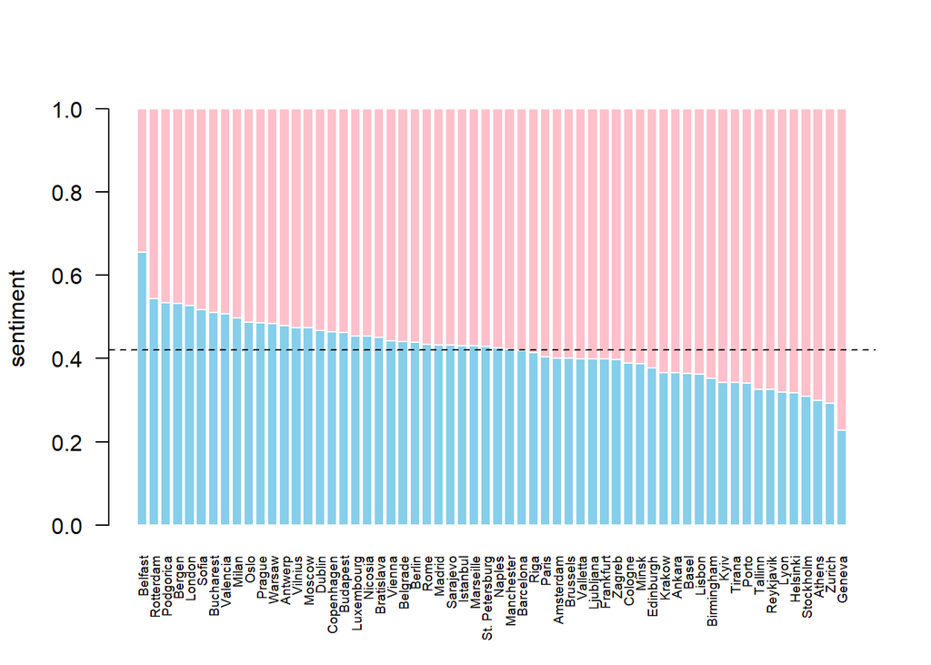

```r
#Create data
data_sentiment<-cbind(as.character(dataset_history$doc_id),unlist(punteggi_neg),unlist(punteggi_pos))
percentage_neg<- ( abs(unlist(punteggi_neg)))/(unlist(punteggi_pos)+abs(unlist(punteggi_neg)))
percentage_pos<- ( unlist(punteggi_pos))/(unlist(punteggi_pos)+abs(unlist(punteggi_neg)))
data_sentiment<-cbind(data_sentiment,perc_pos=percentage_pos,perc_neg=percentage_neg)
data_sentiment<-as.data.frame(data_sentiment)
data_sentiment<-data_sentiment[order(data_sentiment$perc_pos), ]

#dataset_cities_clean<-read.csv2("dataset_cities_clean.txt",stringsAsFactors = F)
data_sentiment$perc_pos<-as.numeric(as.character(data_sentiment$perc_pos))
data_sentiment$perc_neg<-as.numeric(as.character(data_sentiment$perc_neg))

#color palette:
coul = c("#87CEEB","#FFC0CB")

data<-rbind(as.numeric(as.character(data_sentiment[,5])),as.numeric(as.character(data_sentiment[,4])))
colnames(data)<-data_sentiment$V1

par(xpd=F)
barplot(data, col=coul[c(1,2)] , border="white", ylab="sentiment",las=2,cex.names = 0.6)
abline(h=mean(data_sentiment$perc_neg),lty=2,col="black")
```

#### References

Riferimenti:

- [A web scraping website for beginners](https://www.analyticsvidhya.com/blog/2017/03/beginners-guide-on-web-scraping-in-r-using-rvest-with-hands-on-knowledge/);
- [“rvest” package documentation](https://cran.r-project.org/web/packages/rvest/rvest.pdf);
- [Monkeylearn website](https://monkeylearn.com/);
- Lezioni di text mining del corso di LM Data Science dell’Università di Milano-Bicocca (vedi [slides](https://elearning.unimib.it/course/view.php?id=20458) del corso accedendo alla pagina e-learning dell’Università Bicocca);
- [POS tagging for each record in R](https://stackoverflow.com/questions/45287154/pos-tagging-for-each-record-in-r);
- [Dataset latitudini e longitudini delle città](https://raw.githubusercontent.com/bahar/WorldCityLocations/master/World_Cities_Location_table_MS-EXCEL.csv);
- [R graph gallery](https://www.r-graph-gallery.com/) per la mappa interattiva, il grafico degli “history influencers” e le “datadriven-timelines”;